### Original task

Create a function that:

1. Based on the input dataframe (adsl) creates a BWEIGHT to BHEIGHT scatter plot with regression curves, colored by ARM. Also make it possible to define the plot’s title.
2. Make it possible to split the plot by two panels for males and females with the non-splitted layout as default.

```r
library(ggplot2)
library(dplyr)
library(haven)

adsl <- haven::read_sas("data/adsl.sas7bdat")
```

### Solution

```r
f <- function(adsl, title, split = FALSE) {
    p <- ggplot(adsl, aes(BHEIGHT, BWEIGHT, color = ARM)) +
        geom_point() +
        geom_smooth() +
        ggtitle(title)
    if(split) p <- p + facet_wrap(~SEX)
    p
}
```

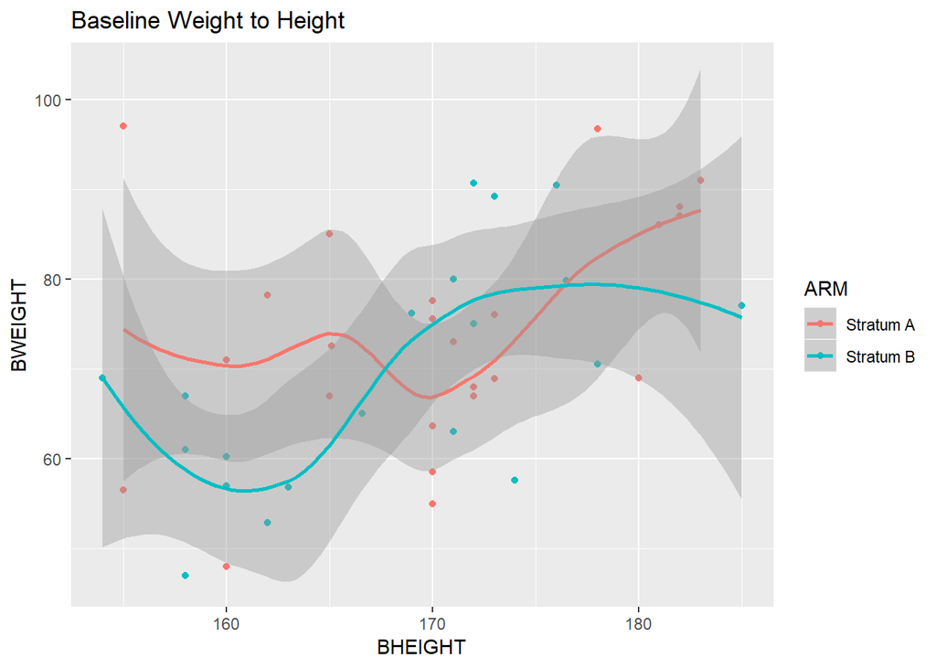

```r
f(adsl, "Baseline Weight to Height")
```

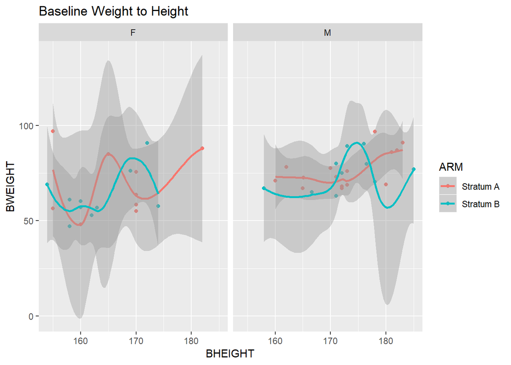

```r
f(adsl, "Baseline Weight to Height", split = TRUE)
```

### Question

Is it possible to define the variable to split by (not necessarily SEX variable) in a function’s attribute?

### Answer

`facet_wrap` allows to define facets with a character vector (see `?facet_wrap`)

```r
f <- function(adsl, title, split = NULL) {
    p <- ggplot(adsl, aes(BHEIGHT, BWEIGHT, color = ARM)) +
        geom_point() +
        geom_smooth() +
        ggtitle(title)
    if(!is.null(split)) p <- p + facet_wrap(split)
    p
}
```

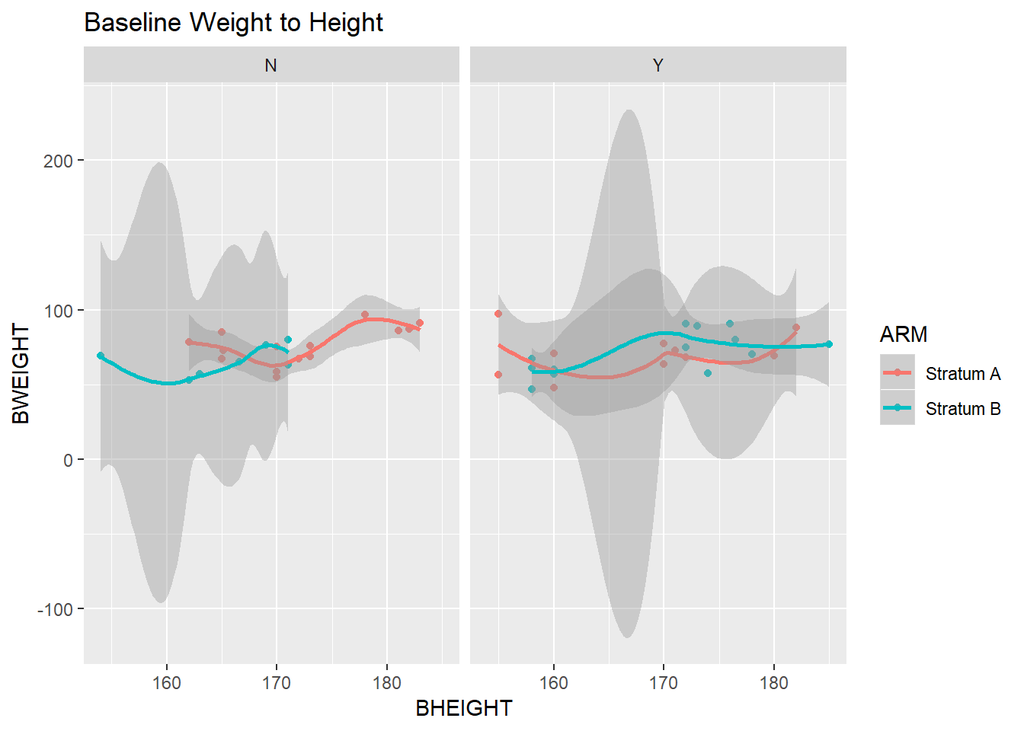

```r
f(adsl, "Baseline Weight to Height", "ITTFL")
```

### Possible Question 1

What about aestetics?

### Answer

This is a bit different: when you quote a name, aestetic will be mapped to a string variable constantly equal to this name.

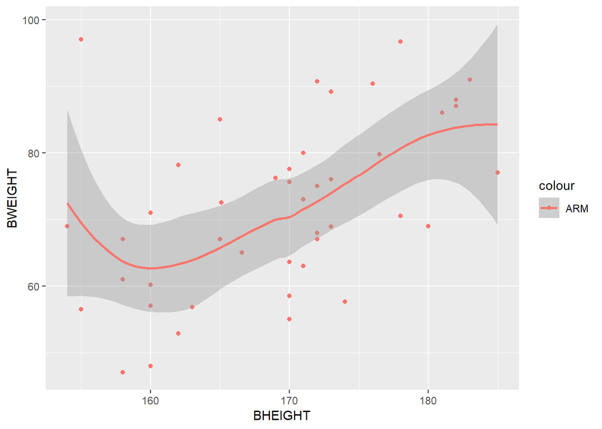

```r
ggplot(adsl, aes(BHEIGHT, BWEIGHT, color = "ARM")) +
        geom_point() +
        geom_smooth()
```

But fortunately there is `aes_string` to help us.

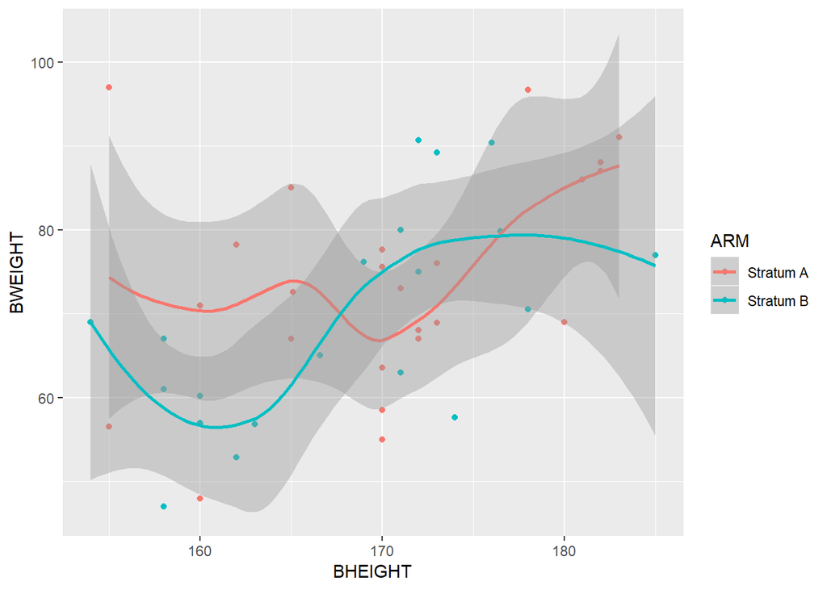

```r
ggplot(adsl, aes_string("BHEIGHT", "BWEIGHT", color = "ARM")) +
        geom_point() +
        geom_smooth()
```

But it seems like the developers will prioritise quasiquotation and `aes_string` will be deprecated in the future [ggplot2 2.2.1.9000 news](https://github.com/tidyverse/ggplot2/blob/master/NEWS.md) (see the first point).

I’m not a big expert in quasiquotation, but if we wanted to write a function, it would probably look like this:

```r
f <- function(adsl, color = NULL) {
    color <- enquo(color)
    ggplot(adsl, aes(BHEIGHT, BWEIGHT, color = !!color)) +
        geom_point() +
        geom_smooth()
}
```

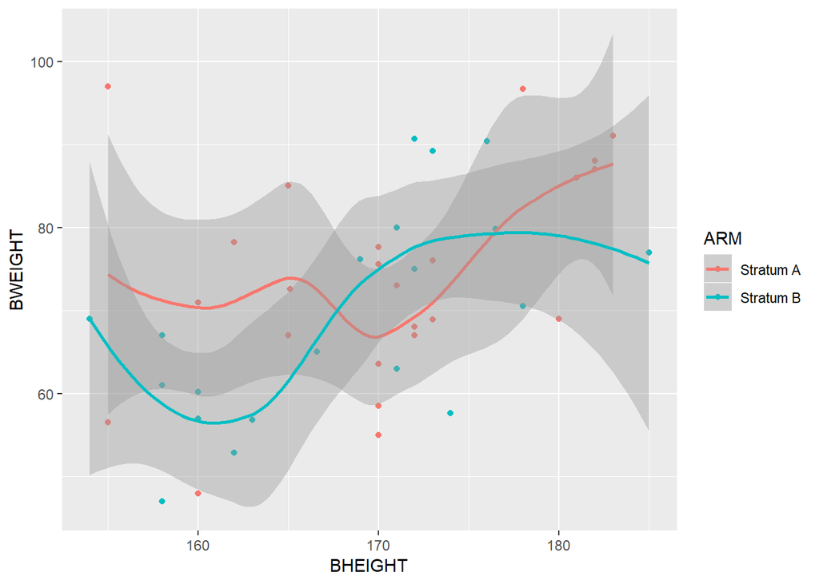

```r
f(adsl, ARM)
```

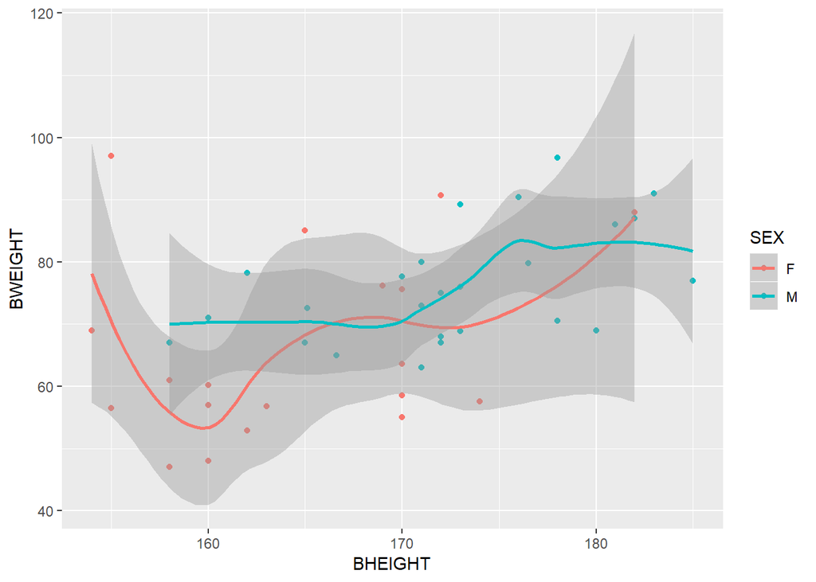

```r
f(adsl, SEX)
```

To get some idea on qq: [Programming with dplyr](https://dplyr.tidyverse.org/articles/programming.html).

#### **NOTE**

To make it work, you need the latest (development) version of ggplot2.

```r
## Ctrl + Shift + F10
install.packages("devtools")
devtools::install_github("r-lib/rlang")
devtools::install_github("tidyverse/ggplot2")
```